# Green split into two donor-disjoint halves, twice: `raw` on an unfloored library and pseudobulk DESeq2 replicate best, `donor_wls` trails because of donors that are outliers on the log scale, and `sta

## 4.2 Among the rules that keep a signal, `raw` on an unfloored library and DESeq2 score best

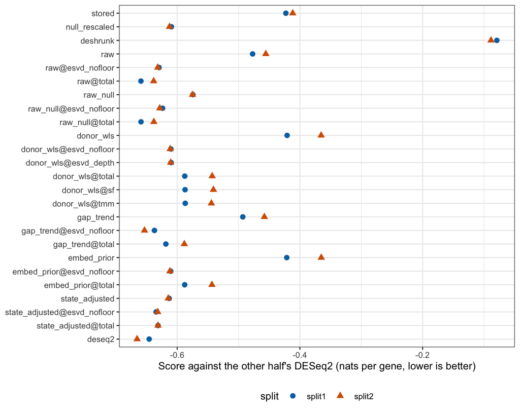

Figure 2. Each method’s pair from one half scored against the other half’s pseudobulk DESeq2 estimate, averaged over the two directions; one point per split.

Without `state_adjusted`, the lowest mean replicate score belongs to `raw@total`, `gap_trend@esvd_nofloor`, `deseq2`, `raw@esvd_nofloor`, in that order, and the lowest mean score against the other half’s DESeq2 to `deseq2`, `raw@total`, `raw_null@total`, `gap_trend@esvd_nofloor`. `gap_trend` is the rule the first loop withdrew because its SE follows the estimated logFC, and it stays withdrawn. Of the rest, `raw@total` scores -0.69 and -0.64, `raw@esvd_nofloor` -0.64 and -0.65, `deseq2` -0.65 and -0.67, `donor_wls@esvd_nofloor` -0.61 and -0.58, `null_rescaled` -0.57 and -0.55 and `stored` -0.26 and -0.26. The four leaders are within 0.09 nats of each other, and `stored` is 0.3 to 0.4 behind them.

**The floor on the library.** The rules as the loops ran them read the fitted library floored at 0.1, and on this cohort that library is costly: `donor_wls` scores -0.37 and -0.18 with it and -0.61 and -0.58 without, and `raw` -0.52 and -0.44 against -0.64 and -0.65. With the floor `donor_wls` has a `z_rms` of 1.20 and 1.34 and its halves correlate at 0.27 and 0.07 over all genes. The Gabitto halves lost 0.05 and 0.01 nats to the floor. A Green donor has a third of the nuclei of a Gabitto donor, and 43% of the genes are at the nuisance cap.

**The library without the floor.** For `raw` the summed counts and the unfloored fitted library are equivalent (-0.69 and -0.64 against -0.64 and -0.65). For `donor_wls` the fitted library is better by 0.08 and 0.20 nats, and `@esvd_depth` equals `@esvd_nofloor` to 0.001, so the gain comes from the gene-specific depth coefficient and not from the covariate columns. Section 4.6 shows that the summed-count version is the one most exposed to outlying donors.

Table 4. The replicate score by gene stratum, mean of the two splits. Genes per stratum in split 1: under 80% zeros 2131; 80 to 95% zeros 2488; over 95% zeros 637; rate estimated 2838; rate at the cap 2418.

| method | under 80% zeros | 80 to 95% zeros | over 95% zeros | rate estimated | rate at the cap |
| --- | --- | --- | --- | --- | --- |
| `stored` | -0.63 | -0.17 | 0.62 | -0.27 | -0.24 |
| `null_rescaled` | -0.78 | -0.57 | 0.21 | -0.58 | -0.54 |
| `raw` | -0.89 | -0.33 | 0.34 | -0.65 | -0.28 |
| `raw@esvd_nofloor` | -0.91 | -0.61 | 0.13 | -0.72 | -0.55 |
| `raw@total` | -0.98 | -0.59 | 0.15 | -0.79 | -0.51 |
| `donor_wls` | -0.32 | -0.33 | 0.10 | -0.37 | -0.17 |
| `donor_wls@esvd_nofloor` | -0.77 | -0.58 | -0.07 | -0.68 | -0.49 |
| `donor_wls@total` | -0.62 | -0.44 | 0.01 | -0.62 | -0.27 |
| `deseq2` | -0.93 | -0.62 | 0.13 | -0.76 | -0.53 |

On Green the rules that lead are `raw` with an unfloored library and pseudobulk DESeq2, with `donor_wls@esvd_nofloor` 0.03 to 0.07 nats behind, where on Gabitto `donor_wls@esvd_nofloor` led by up to 0.06. What holds on both cohorts is that `stored` is far behind and that the floor on the library should go; on Green the floor costs `donor_wls` 0.25 to 0.40 nats.

## 4.3 Correlation over the nominated genes

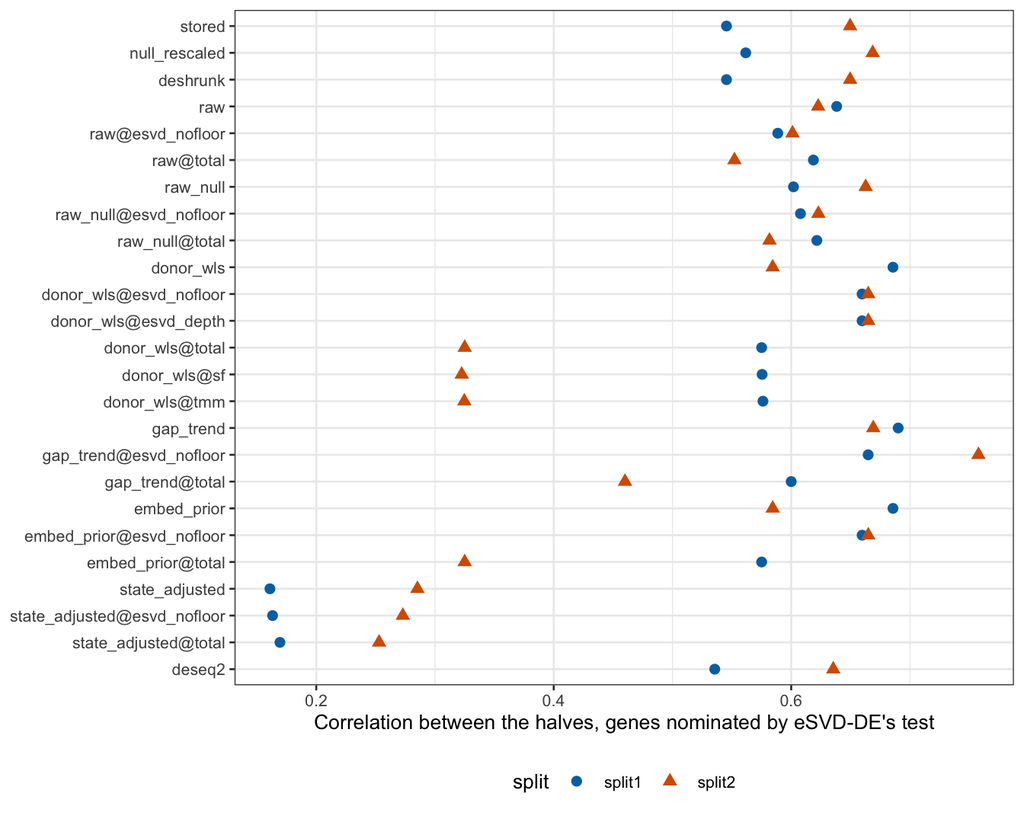

Figure 3. Correlation of the two halves’ logFC over the genes that eSVD-DE’s test nominates in at least one half (the same genes for every method); one point per split.

Over the genes eSVD-DE’s test nominates, the highest mean correlation between the halves belongs to `gap_trend@esvd_nofloor`, `gap_trend`, `donor_wls@esvd_nofloor`, `donor_wls@esvd_depth`. `donor_wls@esvd_nofloor` has 0.66 and 0.66, `raw@esvd_nofloor` 0.59 and 0.60, `raw` 0.64 and 0.62, `stored` 0.55 and 0.65 and `deseq2` 0.54 and 0.64. Over the 135 and 127 genes that DESeq2 nominates, `donor_wls@esvd_nofloor` has 0.73 and 0.81, `raw@esvd_nofloor` 0.68 and 0.53 and `deseq2` 0.65 and 0.58. On the nominated genes, which are the genes with the larger effects, `donor_wls@esvd_nofloor` is at least as good as `raw@esvd_nofloor` in both splits; over all genes the order is the reverse (0.34 and 0.27 against 0.38 and 0.28).

| method | half 1, split1 | half 1, split2 | half 2, split1 | half 2, split2 | both, split1 | both, split2 | sign_rep, split1 | sign_rep, split2 | slope_rep, split1 | slope_rep, split2 |
| --- | --- | --- | --- | --- | --- | --- | --- | --- | --- | --- |
| `null_rescaled` | 89 | 101 | 204 | 97 | 21 | 14 | 0.78 | 0.84 | 0.45 | 0.40 |
| `raw` | 125 | 129 | 319 | 217 | 47 | 48 | 0.87 | 0.86 | 0.58 | 0.71 |
| `raw@esvd_nofloor` | 104 | 112 | 32 | 32 | 11 | 10 | 0.90 | 0.88 | 0.57 | 0.59 |
| `raw@total` | 83 | 106 | 78 | 75 | 23 | 23 | 0.96 | 0.92 | 0.68 | 0.66 |
| `raw_null@esvd_nofloor` | 4 | 4 | 15 | 24 | 3 | 3 | 1.00 | 1.00 | 0.85 | 0.87 |
| `donor_wls` | 47 | 62 | 247 | 268 | 21 | 27 | 0.80 | 0.79 | 0.62 | 0.69 |
| `donor_wls@esvd_nofloor` | 82 | 100 | 24 | 16 | 11 | 8 | 0.92 | 0.93 | 0.68 | 0.69 |
| `donor_wls@total` | 80 | 107 | 57 | 67 | 13 | 13 | 0.85 | 0.83 | 0.64 | 0.65 |
| `deseq2` | 82 | 84 | 70 | 63 | 17 | 20 | 0.89 | 0.88 | 0.65 | 0.54 |

Table 5. Each rule’s own nominations (BH 5% on its Wald test): genes nominated per half and in both, the share of discoveries with the same sign in the other half, and the replication slope.

With 75 controls or more per half the calibrated rules nominate genes of their own, which they could not on Gabitto. `donor_wls@esvd_nofloor` nominates 95 and 108 genes in at least one half and its discoveries keep their sign 92% and 93% of the time; `raw@esvd_nofloor` nominates 125 and 134 with 90% and 88%, and `deseq2` 135 and 127 with 89% and 88%. The package’s test nominates 254 and 173 genes with a sign agreement of 79% and 88%. `null_rescaled` and the floored `raw` and `donor_wls` nominate two to three times as many genes as the unfloored rules at a lower sign agreement.

On the nominated genes `donor_wls@esvd_nofloor` replicates as well as or better than `raw@esvd_nofloor`, and both do better than `stored` in at least one split. The three calibrated tests (`raw@esvd_nofloor`, `donor_wls@esvd_nofloor`, DESeq2) nominate 95 to 135 genes per split whose sign holds in the other half about nine times in ten, against eight in ten for the package’s test.

## 4.4 The SE against the disagreement between the halves

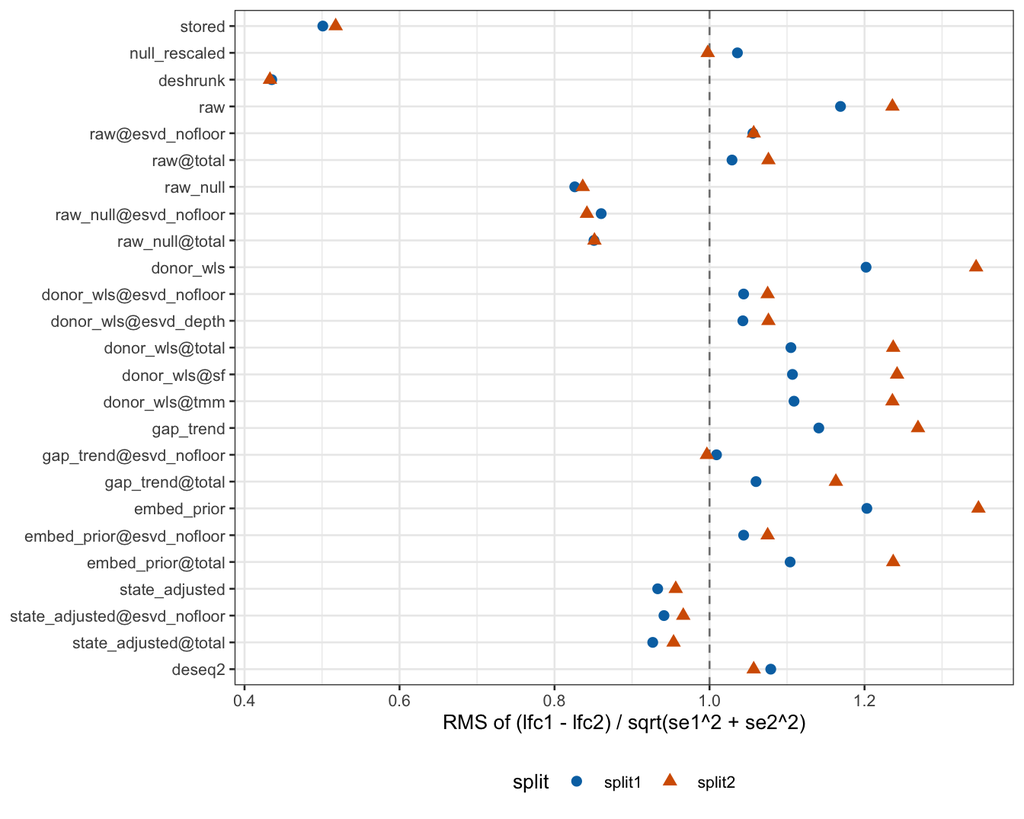

Figure 4. Root mean square of the standardized difference between the halves; 1 (dashed) means the SEs explain the disagreement, below 1 that they are too large.

The `stored` SE gives a `z_rms` of 0.50 and 0.52, an SE about twice the one that would explain the disagreement between the halves (2.3 to 2.6 times on Gabitto). `null_rescaled` is at 1.04 and 1.00: the empirical null’s SD of 0.44 to 0.59 repairs the `stored` SE on this cohort over all genes, with 1.25 and 1.12 for the genes under 80% zeros and 0.85 and 0.86 for those over 95%. `raw@esvd_nofloor` is at 1.06 and 1.06, `donor_wls@esvd_nofloor` at 1.04 and 1.07 and `deseq2` at 1.08 and 1.06, all slightly too small. On Gabitto `donor_wls@esvd_nofloor` was at 0.85 to 0.89, so its SE moved from about 15% too large with 40 donors to about 6% too small with 214. The floored `raw` and `donor_wls` are at 1.17 and 1.24 and 1.20 and 1.34.

The stored SE is twice too large on Green as well. The SEs of `raw@esvd_nofloor`, `donor_wls@esvd_nofloor` and DESeq2 are 4 to 8% too small against the disagreement between the halves, close enough that the choice between the three rules does not rest on calibration.

## 4.5 Does a nominated gene keep its sign in the other half?

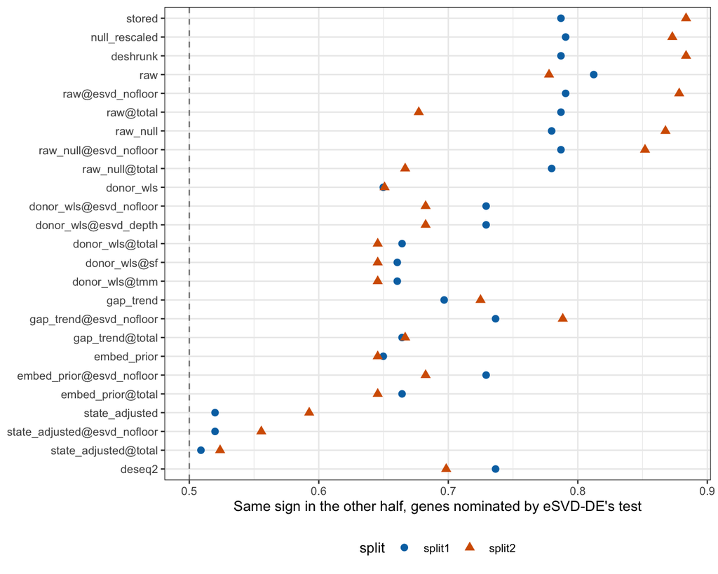

Figure 5. Share of the genes called by eSVD-DE’s test in one half whose logFC, under each method, has the same sign in the other half; one point per split.

Table 6. The genes eSVD-DE’s test calls at 5% FDR in one half, by group. `sign_rep` uses the `stored` logFC of the two halves and `sign_rep_wls` that of `donor_wls@esvd_nofloor`; `slope_rep` is the replication slope of the `stored` logFC; the `donor_wls` p-value is the nominal Wald p of `donor_wls@esvd_nofloor` in the discovering half.

| split | group | num_calls | sign_rep | sign_rep_wls | slope_rep | median_abs_lfc |
| --- | --- | --- | --- | --- | --- | --- |
| split1 | all calls | 277 | 0.79 | 0.73 | 0.50 | 0.28 |
| split1 | rate estimated | 163 | 0.74 | 0.75 | 0.52 | 0.32 |
| split1 | rate at the cap | 114 | 0.85 | 0.70 | 0.45 | 0.27 |
| split1 | donor_wls p < 0.05 | 187 | 0.79 | 0.81 | 0.62 | 0.31 |
| split1 | donor_wls p >= 0.05 | 90 | 0.79 | 0.57 | -0.05 | 0.26 |
| split1 | donor_wls p < 0.01 | 141 | 0.86 | 0.88 | 0.65 | 0.35 |
| split2 | all calls | 189 | 0.88 | 0.68 | 0.58 | 0.32 |
| split2 | rate estimated | 108 | 0.88 | 0.89 | 0.65 | 0.37 |
| split2 | rate at the cap | 81 | 0.89 | 0.41 | 0.38 | 0.30 |
| split2 | donor_wls p < 0.05 | 119 | 0.91 | 0.92 | 0.75 | 0.36 |
| split2 | donor_wls p >= 0.05 | 70 | 0.84 | 0.29 | 0.09 | 0.30 |
| split2 | donor_wls p < 0.01 | 93 | 0.94 | 0.96 | 0.80 | 0.39 |

Of the genes eSVD-DE’s test calls in one half, 79% and 88% have a `stored` logFC of the same sign in the other half (Table 6), which bounds the share of null genes among the calls at 43% and 23% (a null gene keeps its sign half the time). The Gabitto halves had 81% and 66%.

The two flags of the Gabitto report behave differently here. A call whose gene has its nuisance rate at the cap keeps its `stored` sign 85% and 89% of the time against 74% and 88% for the other calls, so the capped calls replicate at least as well, as they did in the comparison with Prater. A call that `donor_wls@esvd_nofloor` supports at nominal $p < 0.05$ keeps its `stored` sign 79% and 91% of the time against 79% and 84% for the unsupported calls, a difference of a few points. The unsupported calls differ in another respect: their replication slope is -0.05 and 0.09 against 0.62 and 0.75, and under the `donor_wls@esvd_nofloor` logFC their sign holds 57% and 29% of the time. For these genes the posterior-based logFC and the donor-level logFC disagree, the first keeps a small effect of stable sign in both halves, and the second does not see it.

About eight to nine of ten eSVD-DE calls keep their sign in the other half on Green. Neither the nuisance status nor the `donor_wls` p-value separates the calls that keep their `stored` sign from those that do not, so step 4 of the Gabitto procedure (treat a capped or unsupported call as provisional) does not carry over as a rule. The unsupported calls are genes on which the posterior-based and the donor-level estimates disagree in size and sign.

## 4.6 Why `donor_wls` trails `raw` here: donors that are outliers on the log scale

`donor_wls` and `raw` were handed the same library in the `@total` variants, and their halves agree very differently on the well-expressed genes: 0.45 and 0.39 for `raw@total` against 0.16 and -0.21 for `donor_wls@total` over the genes with under 80% zeros, and 0.25 and 0.24 against -0.00 and -0.35 over the genes at the cap. `donor_wls` reads the counts and the library only through their sums per donor, so `05_diagnose-donor-wls_claude.R` reran it from the donor pseudobulk with one step changed at a time; the unchanged version reproduces the stored `donor_wls@total` exactly.

Table 7. Green: correlation of the logFC between the halves for versions of `donor_wls` with the summed-count library, over all genes, the genes with under 80% zeros and the genes at the nuisance cap. `no covariates` leaves the intercept and the arm in the donor-level design; `winsorized` pulls each gene’s log donor means to within 3 MADs of the gene’s median before anything is fitted.

| version | all, split1 | all, split2 | zeros_below_80, split1 | zeros_below_80, split2 | rate_capped, split1 | rate_capped, split2 |
| --- | --- | --- | --- | --- | --- | --- |
| as the rule | 0.25 | 0.02 | 0.16 | -0.21 | 0.00 | -0.35 |
| no donor offset | 0.25 | 0.02 | 0.16 | -0.21 | 0.00 | -0.35 |
| no weights | 0.23 | -0.01 | 0.15 | -0.23 | -0.01 | -0.37 |
| no covariates | 0.41 | 0.25 | 0.39 | 0.04 | 0.18 | -0.07 |
| no covariates, no offset, no weights | 0.41 | 0.24 | 0.39 | 0.04 | 0.19 | -0.07 |
| as the rule, winsorized | 0.35 | 0.35 | 0.32 | 0.34 | 0.14 | 0.04 |
| no covariates, winsorized | 0.50 | 0.50 | 0.50 | 0.48 | 0.29 | 0.28 |
| raw (donor sums) | 0.42 | 0.32 | 0.48 | 0.41 | 0.26 | 0.27 |
| raw@total (stored) | 0.40 | 0.27 | 0.45 | 0.39 | 0.25 | 0.24 |
| deseq2 (stored) | 0.36 | 0.28 | 0.33 | 0.31 | 0.20 | 0.13 |

Table 8. The same on the Gabitto halves.

| version | all, split1 | all, split2 | zeros_below_80, split1 | zeros_below_80, split2 | rate_capped, split1 | rate_capped, split2 |
| --- | --- | --- | --- | --- | --- | --- |
| as the rule | 0.43 | 0.53 | 0.50 | 0.48 | 0.46 | 0.49 |
| no donor offset | 0.43 | 0.53 | 0.50 | 0.48 | 0.46 | 0.49 |
| no weights | 0.40 | 0.52 | 0.49 | 0.48 | 0.46 | 0.48 |
| no covariates | 0.48 | 0.52 | 0.54 | 0.58 | 0.53 | 0.44 |
| no covariates, no offset, no weights | 0.44 | 0.52 | 0.52 | 0.60 | 0.52 | 0.52 |
| as the rule, winsorized | 0.44 | 0.54 | 0.51 | 0.48 | 0.48 | 0.51 |
| no covariates, winsorized | 0.49 | 0.53 | 0.54 | 0.59 | 0.54 | 0.47 |
| raw (donor sums) | 0.43 | 0.39 | 0.54 | 0.53 | 0.53 | 0.19 |
| raw@total (stored) | 0.39 | 0.39 | 0.51 | 0.51 | 0.47 | 0.34 |
| deseq2 (stored) | 0.37 | 0.35 | 0.51 | 0.42 | 0.37 | 0.20 |

**How many such donors.** Over the genes with under 80% zeros, 2.3% of the log donor means of the Green cohort lie more than 3 MADs below the gene’s median and 1.3% more than 5, where a Gaussian has 0.1% beyond 3; on the Gabitto cohort the shares are 0.8% and 0.04%. A Green outlier is 2.1 below the median on the natural-log scale on average, about an eighth of the typical expression, and a Gabitto one 0.8. The Green outliers sit in a minority of donors: 12% of the donors have a tenth or more of their genes below the threshold (the largest share is 25%; no Gabitto donor is above 5%), and a donor’s share correlates at -0.62 with its log depth per nucleus, so they are the donors sequenced most shallowly.

The unfloored fitted library softens the problem without removing it (`donor_wls@esvd_nofloor` has 0.26 and 0.09 over the genes with under 80% zeros, against 0.40 and 0.41 for `raw@esvd_nofloor`).

`donor_wls` loses to `raw` on Green because it averages logarithms over donors of whom about one in nine is far below the rest for a tenth or more of its genes; `raw` averages on the natural scale and is not moved by a donor with low expression. Winsorized log donor means agree between the halves better than either rule. The donor-level covariates of `donor_wls` cost agreement on this cohort and make little difference on Gabitto.

## 4.7 Green beside Gabitto

Table 9. The two cohorts side by side, each number the mean of the cohort’s two splits. The scores are not comparable between cohorts (the SEs are smaller with more donors); the order of the rules within a cohort is.

| method | score, Gabitto | score, Green | score_cross, Gabitto | score_cross, Green | z_rms, Gabitto | z_rms, Green | corr_all, Gabitto | corr_all, Green | corr_nominated, Gabitto | corr_nominated, Green | sign_rep, Gabitto | sign_rep, Green |
| --- | --- | --- | --- | --- | --- | --- | --- | --- | --- | --- | --- | --- |
| `stored` | 0.48 | -0.26 | 0.27 | -0.42 | 0.40 | 0.51 | 0.39 | 0.37 | 0.48 | 0.60 | 0.73 | 0.84 |
| `null_rescaled` | 0.01 | -0.56 | -0.13 | -0.61 | 1.13 | 1.02 | 0.39 | 0.38 | 0.49 | 0.62 | 0.73 | 0.83 |
| `raw@esvd_nofloor` | -0.21 | -0.65 | -0.17 | -0.63 | 0.99 | 1.06 | 0.36 | 0.33 | 0.49 | 0.59 | 0.73 | 0.83 |
| `raw@total` | -0.21 | -0.66 | -0.18 | -0.65 | 0.93 | 1.05 | 0.39 | 0.33 | 0.57 | 0.59 | 0.78 | 0.73 |
| `donor_wls` | -0.21 | -0.27 | -0.19 | -0.39 | 0.90 | 1.27 | 0.44 | 0.17 | 0.60 | 0.64 | 0.76 | 0.65 |
| `donor_wls@esvd_nofloor` | -0.24 | -0.60 | -0.21 | -0.61 | 0.87 | 1.06 | 0.44 | 0.30 | 0.58 | 0.66 | 0.76 | 0.71 |
| `donor_wls@total` | -0.21 | -0.46 | -0.19 | -0.57 | 0.89 | 1.17 | 0.48 | 0.14 | 0.60 | 0.45 | 0.78 | 0.65 |
| `state_adjusted` | -0.62 | -0.98 | -0.10 | -0.61 | 1.03 | 0.94 | 0.00 | 0.12 | 0.01 | 0.22 | 0.51 | 0.56 |
| `deseq2` | -0.18 | -0.66 | -0.18 | -0.66 | 0.93 | 1.07 | 0.36 | 0.32 | 0.50 | 0.59 | 0.75 | 0.72 |

The two cohorts agree on four things: `stored` has the worst score of the rules that keep a signal and an SE two to two and a half times too large; `state_adjusted` wins the replicate score with no agreement between its halves; removing the floor from the library helps every rule that reads it; and the calibrated rules are within 0.08 nats of each other and of DESeq2. They disagree on the order of `raw@esvd_nofloor` and `donor_wls@esvd_nofloor`: `donor_wls@esvd_nofloor` leads on Gabitto by 0.03 nats on average and trails on Green by 0.05.

Between the two candidates for the reported pair the cohorts split: `donor_wls@esvd_nofloor` on Gabitto (80 donors of about 500 nuclei), `raw@esvd_nofloor` on Green (428 donors of about 190). The reason on Green is identified (section 4.6) and is a property of the mean of logarithms with many small donors.

# 5 Recommendation

**Which rule on this cohort.** By the replicate score and the score against an independent DESeq2 estimate, `raw@esvd_nofloor` is the best rule from eSVD-DE on Green that the loops did not withdraw, level with `raw@total` and DESeq2, and its SE is 6% too small against the disagreement between the halves. This is a consequence of the evidence above. `donor_wls@esvd_nofloor`, the recommendation of the Gabitto report, is 0.03 to 0.07 nats behind it, replicates as well on the nominated genes, and loses on the well-expressed genes for the reason of section 4.6.

**Which library.** Without the floor, in every case (a consequence, measured at 0.13 to 0.40 nats on this cohort). Between the unfloored fitted library and the summed counts, `raw` is indifferent and `donor_wls` is better with the fitted library.

**Which rule not.** `state_adjusted` (a consequence, second cohort), `stored` as the reported SE (a consequence, fourth time measured), and any rule with the floored library on a cohort of this shape.

**How to read an eSVD-DE call.** The sign of a call holds in the other half 79% and 88% of the time. The two flags of the Gabitto procedure do not identify the calls that fail here, so no flag is recommended from this cohort (a consequence).

1. Fit the cohort with `eSVD2::eSVD_helper()` as now.
2. Rebuild the counts and the covariates of the fit and form the fitted library without the posterior’s floor, the exponential of the fit’s linear predictor over every covariate but the arm.
3. Report the log2 fold change and its SE from `raw@esvd_nofloor`.
4. Beside it, compute `donor_wls@esvd_nofloor` and the share of log donor means more than 3 MADs below the gene’s median (2.3% here, 0.8% on Gabitto). Where the two logFC of a gene disagree in sign or by more than their SEs, the gene’s log donor means should be inspected for outlying donors.
5. Check on a split of the cohort’s donors, as here, that the reported rule’s two halves correlate over the nominated genes and over the well-expressed genes.
6. Replacement: on a cohort with few donors of many cells each (the Gabitto shape), `donor_wls@esvd_nofloor` is the pair to report, as in the Gabitto report. The final choice between the two rules across cohort shapes is made in `2026-11-16_autoresearch_beyond-score_claude.Rmd`, which has the simulated evidence beside both cohorts.

**What the autoresearch bank should add.** Three things on this cohort were outside what the banks could show, beyond the four of the Gabitto report.

1. *Donors that are outliers on the log scale.* Every bank draws donor effects from a Gaussian on the log scale, under which a mean of logarithms is the efficient summary. Examples in which a tenth of the donors lie far below the others for a share of their genes, at the rate and size measured here, separate `raw` from `donor_wls` in simulation.
2. *Many donors of few cells.* The banks stop at 40 donors. Examples with 200 donors of 50 to 200 cells have small per-donor counts for most genes, which is where the half count and the logarithm of `donor_wls` matter.
3. *A capped share near 40%.* The Gabitto halves have 17% of genes at the cap and the Green halves 43%, with the floor on the library costing several times as much.

The fourth bank, `lfcse-bank-4`, has these three beside the four of the Gabitto report; it is described and scored in `2026-11-16_autoresearch_beyond-score_claude.Rmd`. With outlying donors drawn at Green’s rate it reproduces the order found here (`donor_wls` behind `raw` and DESeq2), and with Gaussian donors `donor_wls` is ahead of `raw` at 200 donors as at 40, so the number of donors is not what reverses the order.

# 6 What we glossed over

- **Two splits of one cohort.** The two splits share all 428 donors, and 196 donors have the same half label in both, so their agreement is not independent confirmation. Differences of under 0.03 nats or 0.05 in a correlation are within the variation between the splits.
- **Shared bias is invisible to a split.** A bias common to both halves cancels in the difference and raises the correlation. The simulated banks, which have a truth, are the evidence against such a bias, and the score against the other half’s DESeq2 is a partial check.
- **Why the shallow donors are outlying was not examined.** Section 4.6 shows that bounding each gene’s log donor means restores the agreement and that the outlying values sit in the donors of low depth per nucleus; whether the cause is technical (ambient RNA, a batch) or a distinct microglial state was not studied. Winsorized log donor means are a diagnostic here and not a proposed rule.
- **Why the covariates cost agreement was not dissected.** APOE4 status differs between the arms (9 of 76 controls against 46 of 138 cases per half), so the arm coefficient loses precision to it; whether that accounts for the whole loss was not tested.
- **One fit used a fallback null.** In `split2_half2` `locfdr` did not converge and the package’s test used its truncated maximum-likelihood estimator (null SD 0.44, within the range of the other three fits).
- **The rules’ own tests use a normal reference**, which matters little with 208 residual degrees of freedom.
- **Each half has half the cohort’s power**, so the counts of nominated genes describe cohorts of 214 donors.
- **Batch and study are not adjusted for**, as in Writeup47 (127 batches, two studies, ROS and MAP), and no split stratified on them, on PMI or on age at death (Table 1 shows the realized means).
- **The fits stopped after 9 to 11 iterations per phase** at the default tolerance and took 66 to 83 minutes each. Four fits at once need about 50 GB during the nuisance step, more than the laptop’s 32 GB, and two of them were paused until the other two had finished.
- **Why `state_adjusted` loses the signal is still not dissected**; the rank explanation of the Gabitto report is ruled out as sufficient.

# 7 Files

All paths are relative to `additional_context/2026-11-16_green/` unless they start with `OUT`, which is `out/2026-11-16_green/` beside the repository clone (not in git).

[output not shown]

# 8 References

- Green et al. (2024), *Cellular communities reveal trajectories of brain ageing and Alzheimer’s disease*, Nature 633:634, doi:10.1038/s41586-024-07871-6 (the cohort). *Verify before citing.*
- Gabitto et al. (2024), *Integrated multimodal cell atlas of Alzheimer’s disease*, Nature Neuroscience, doi:10.1038/s41593-024-01774-5. *Verify before citing.*
- Lin, Qiu and Roeder (2024), *eSVD-DE*, BMC Bioinformatics 25:113, doi:10.1186/s12859-024-05724-7.
- Love, Huber and Anders (2014), DESeq2, Genome Biology 15:550, doi:10.1186/s13059-014-0550-8.
- `additional_context/2026-11-15_gabitto/2026-11-15_gabitto-split-half_claude.Rmd` (the study this one repeats).
- `additional_context/2026-11-12_autoresearch_beyond-score_claude.Rmd` (the rules on the three simulated banks) and `additional_context/2026-11-16_autoresearch_beyond-score_claude.Rmd` (its new version, with the fourth bank and the final recommendation).
- `autoresearch_lfcse/notes/RUN_nov11_claude.md`, `autoresearch_lfcse2/notes/RUN_nov11_claude.md` (the two loops).
- `WAS2CODE_ANALYSIS_REPO`, `code/tati/Writeup47_green_final-de/` (the design).